# 04_Wenas_meta_stats

2023-07-11

## Load packages and set working directory

```r
#for Jake/mac

rm(list=ls(all=T)) #this clears your Environment


library(tidyverse)
library(rstatix)
```

```r
library(ggpubr)
library(ggplot2)
library(coin)
library(dotwhisker)
library(dplyr)
library(lme4)
library(emmeans)
```

### STEP 1 load in the data and normalize data

```r
#import Metadata sheet that is stored on Google Sheet
percent_difference <- read_csv("~/GitHub/rc_sfa-rc-3-wenas-modeling/Lit_Review_Fig/Output_for_analysis/analyte_table_DOC_no3.csv")
# log transform the percentages
percent_difference <- percent_difference %>%
  mutate(log_pd = log(abs(Percent_Difference))) # should I be taking the absolute value of the negative percent_differences?

percent_difference_DOC <- percent_difference %>%
  filter(response_var == "DOC_mg_C_L")

percent_difference_NO3 <- percent_difference %>%
  filter(response_var == "NO3_mg_per_L_as_Nitrate")
```

### STEP 2 check normality for DOC

```r
summary(percent_difference_DOC$Percent_Difference)
```

```
##    Min. 1st Qu.  Median    Mean 3rd Qu.    Max.
##  -60.75   12.22   33.61   39.06   70.08  119.78
```

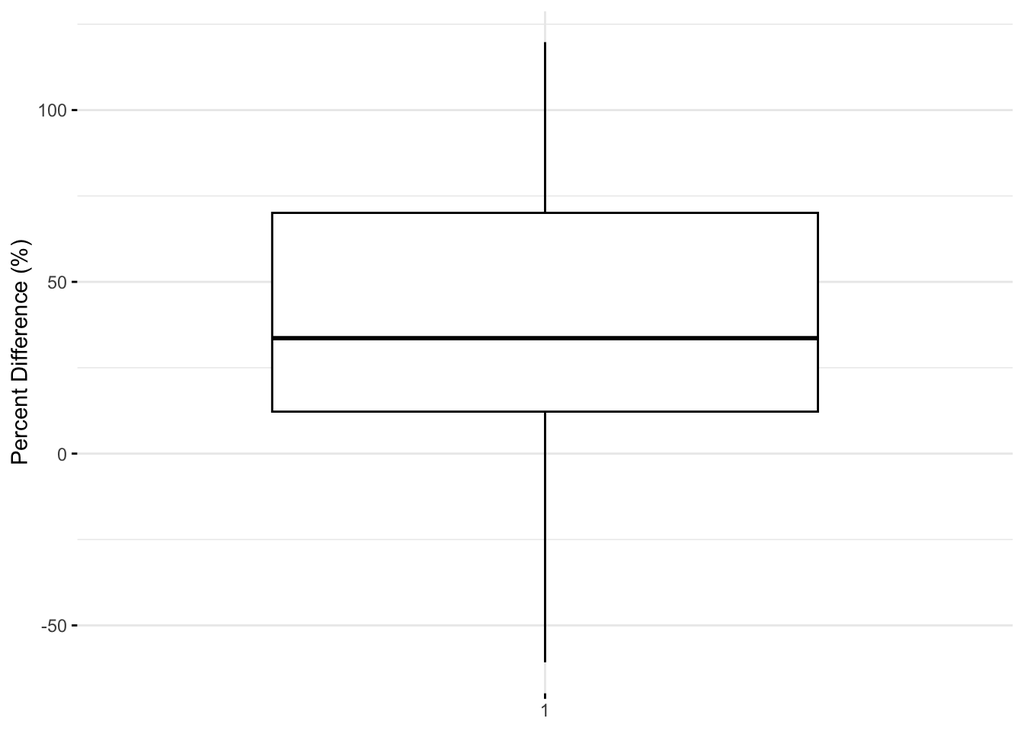

```r
#Visualize data
ggboxplot(percent_difference_DOC$Percent_Difference,
          ylab = "Percent Difference (%)", xlab = FALSE,
          ggtheme = theme_minimal())
```

```r
#perform shapiro-wilk test
shapiro.test(percent_difference_DOC$Percent_Difference)
```

```
##
##  Shapiro-Wilk normality test
##
## data:  percent_difference_DOC$Percent_Difference
## W = 0.98185, p-value = 0.8513
```

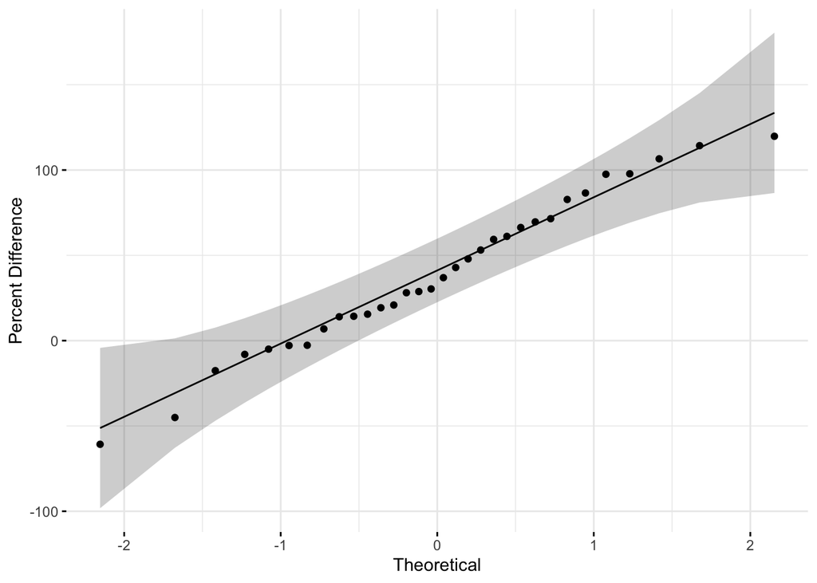

```r
# checking to see if the data is normal
ggqqplot(percent_difference_DOC$Percent_Difference, ylab = "Percent Difference",
         ggtheme = theme_minimal())
```

```r
# p-value is greater than 0.05 which indicates that the data is normally distributed
```

The percent differences for DOC are already normally distributed and do NOT need to be transformed.

### STEP 3 perform t-test for DOC

```r
#
res <- t.test(percent_difference_DOC$Percent_Difference, mu = 0)
# printing the results
res
```

```
##
##  One Sample t-test
##
## data:  percent_difference_DOC$Percent_Difference
## t = 4.884, df = 31, p-value = 2.994e-05
## alternative hypothesis: true mean is not equal to 0
## 95 percent confidence interval:
##  22.74849 55.36954
## sample estimates:
## mean of x
##  39.05901
```

### STEP 4 do the same thing for nitrate

```r
###  check normality for NO3 ###
summary(percent_difference_NO3$Percent_Difference)
```

```
##    Min. 1st Qu.  Median    Mean 3rd Qu.    Max.
##  -94.74   37.41  160.00  183.26  308.24  807.51
```

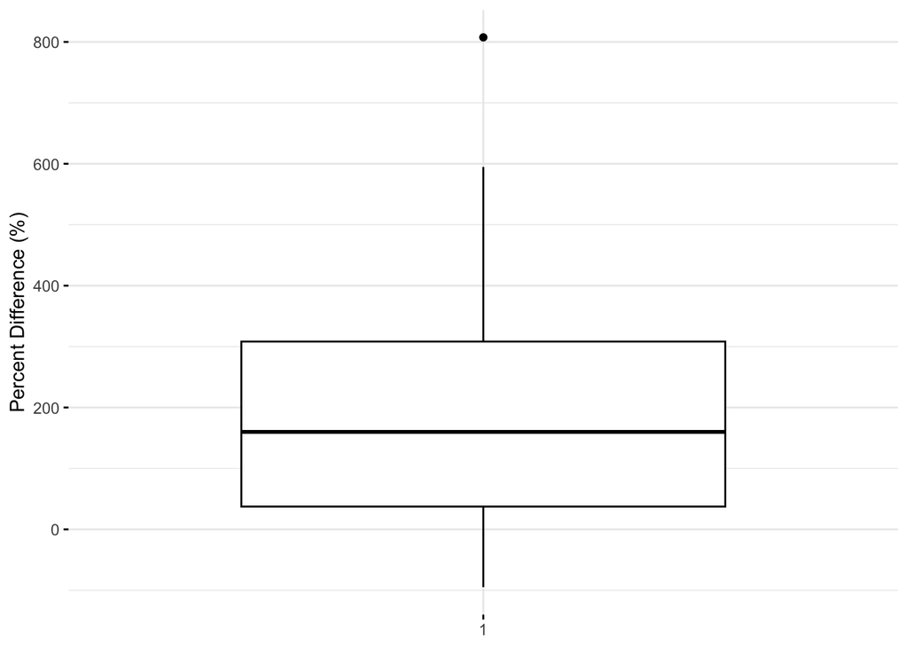

```r
#Visualize data
ggboxplot(percent_difference_NO3$Percent_Difference,
          ylab = "Percent Difference (%)", xlab = FALSE,
          ggtheme = theme_minimal())
```

```r
#perform shapiro-wilk test
shapiro.test(percent_difference_NO3$Percent_Difference)
```

```
##
##  Shapiro-Wilk normality test
##
## data:  percent_difference_NO3$Percent_Difference
## W = 0.92129, p-value = 0.003705
```

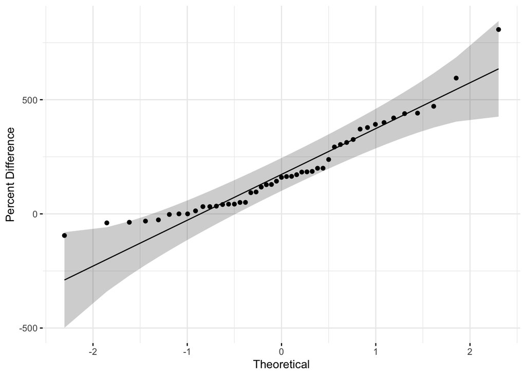

```r
# p-value is less than 0.05 which indicates that the data is normally distributed


# checking to see if the data is normal
ggqqplot(percent_difference_NO3$Percent_Difference, ylab = "Percent Difference",
         ggtheme = theme_minimal())
```

The percent differences for nitrate do not appear to be normally distributed so lets do a log transform

```r
#perform shapiro-wilk test
shapiro.test(percent_difference_NO3$log_pd)
```

```
##
##  Shapiro-Wilk normality test
##
## data:  percent_difference_NO3$log_pd
## W = NaN, p-value = NA
```

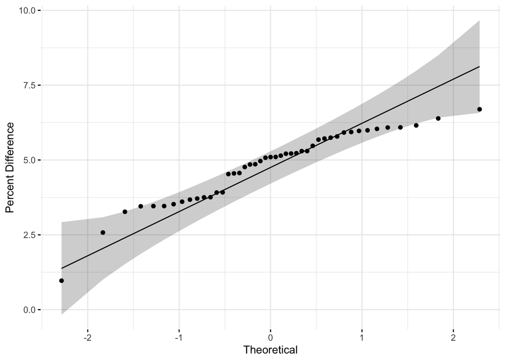

```r
# p-value is less than 0.05 which indicates that the data is normally distributed


# checking to see if the data is normal
ggqqplot(percent_difference_NO3$log_pd, ylab = "Percent Difference",
         ggtheme = theme_minimal())
```

I don’t think this looks better than the non-log transformed. What should we go with here?

```r
#
res <- t.test(percent_difference_NO3$Percent_Difference, mu = 0)
# printing the results
res
```

```
##
##  One Sample t-test
##
## data:  percent_difference_NO3$Percent_Difference
## t = 6.6339, df = 46, p-value = 3.232e-08
## alternative hypothesis: true mean is not equal to 0
## 95 percent confidence interval:
##  127.6516 238.8619
## sample estimates:
## mean of x
##  183.2567
```

#### STEP 5 Do CIs of effect size overlap with 0

This will tell us if the effect sizes are significant or not

```r
# rm(list=ls(all=T)) #this clears your Environment


library(tidyverse)
library(rstatix)
library(ggpubr)
library(ggplot2)
library(coin)
library(dotwhisker)

effect_size <- read_csv("~/GitHub/rc_sfa-rc-3-wenas-modeling/Lit_Review_Fig/Output_for_analysis/analyte_table_effect_DOC_no3.csv")
effect_size_DOC <- effect_size %>%
  filter(response_var == "DOC_mg_C_L")

effect_size_NO3 <- effect_size %>%
  filter(response_var == "NO3_mg_per_L_as_Nitrate")
```

### I want to see the relationship between the effect size and percent change that Peter looked at really quickly with the Dove paper

```r
# relationship between effect size and percent change
percent_difference %>%
  count(Study_ID)
```

```
## # A tibble: 16 × 2
##    Study_ID     n
##       <dbl> <int>
##  1        1     4
##  2        2     3
##  3        3     1
##  4        4     2
##  5        5     4
##  6        9     2
##  7       10     2
##  8       11    18
##  9       12     5
## 10       15     8
## 11       16     6
## 12       17     3
## 13       21     4
## 14       22     6
## 15       26     2
## 16       27     9
```

```r
effect_size %>%
  count(Study_ID)
```

```
## # A tibble: 16 × 2
##    Study_ID     n
##       <dbl> <int>
##  1        1     4
##  2        2     3
##  3        3     1
##  4        4     2
##  5        5     4
##  6        9     2
##  7       10     2
##  8       11    18
##  9       12     5
## 10       15     8
## 11       16     7
## 12       17     3
## 13       21     4
## 14       22     6
## 15       26     2
## 16       27     9
```

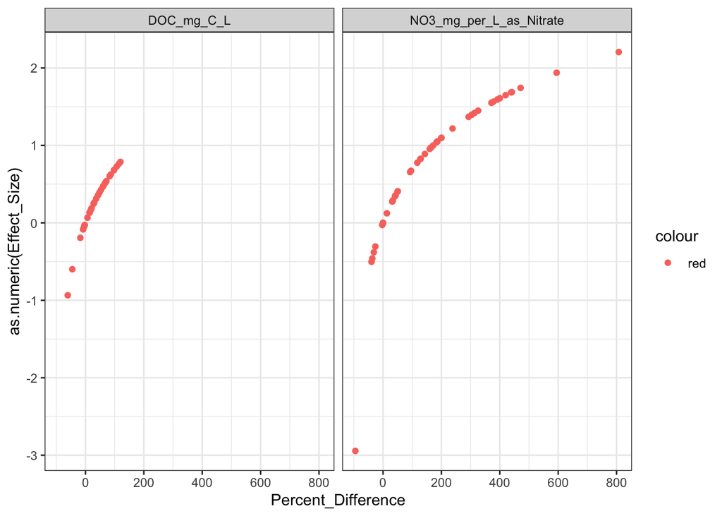

```r
es <- effect_size %>%
  filter(!row_number() %in% c(37))

pd_es <- percent_difference %>%
  select("Study_ID", "response_var", "Percent_Difference") %>%
  mutate(Effect_Size = paste(es$Effect_size))

ggplot(pd_es) +
  geom_point(aes(x = Percent_Difference, y = as.numeric(Effect_Size), color = "red")) +
  facet_wrap(~response_var) +
  theme_bw()
```

The equation for percent change in Dove’s paper is D = 100(1-e^ln(R))

This looks like a log relationship so is there where they get that equation for the relationship between effect size and percent change…

### CALCULATING CI

```r
# Calculating a confidence interval for all of the effect sizes
# calculating the mean effect_size by climate
climate_summary_effect <- effect_size %>%
  group_by(Koppen, response_var, Climate) %>%
  summarise(sd_effect = sd(Effect_size, na.rm = TRUE),
            n_effect = n(),
            Effect_size = mean(Effect_size, na.rm = TRUE)) %>%
 mutate(se_effect = sd_effect / sqrt(n_effect),
         lower_ci_effect = Effect_size - qt(1 - (0.05 / 2), n_effect - 1) * se_effect,
         upper_ci_effect = Effect_size + qt(1 - (0.05 / 2), n_effect - 1) * se_effect)
# Calculating a confidence interval for all of the effect sizes
# calculating the mean effect_size by climate
TSF_summary_effect <- effect_size %>%
  group_by(TSF, response_var) %>%
  summarise(sd_effect = sd(Effect_size, na.rm = TRUE),
            n_effect = n(),
            Effect_size = mean(Effect_size, na.rm = TRUE)) %>%
 mutate(se_effect = sd_effect / sqrt(n_effect),
         lower_ci_effect = Effect_size - qt(1 - (0.05 / 2), n_effect - 1) * se_effect,
         upper_ci_effect = Effect_size + qt(1 - (0.05 / 2), n_effect - 1) * se_effect)
```

[output not shown]

### PLOTS

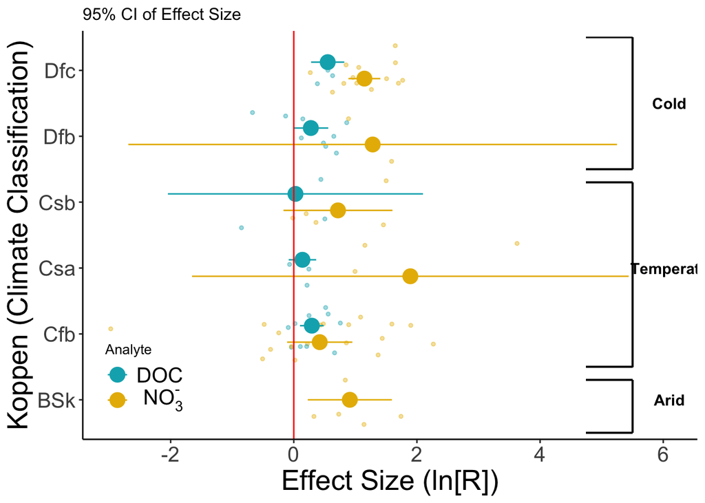

```r
### Plotting ###

# Ploting #
vn = expression(paste(""*N*O[3]^"-"))

# geom_jitter for climate #
ggplot(effect_size, aes(Effect_size, Koppen, color = response_var),
       position = position_dodge(width = -0.5)) +
  geom_jitter(position = position_jitter(0.1), alpha = 0.4, size = 1) +
  geom_pointrange(aes(xmin = lower_ci_effect, xmax = upper_ci_effect,
                      color = response_var),
                      position = position_dodge(width = -0.5), size = 1.0, data = climate_summary_effect) +
  geom_vline(xintercept = 0, linewidth = 0.5, color = "red") +
  ylab("Koppen (Climate Classification)") +
  xlab("Effect Size (ln[R])") +
  ggtitle("95% CI of Effect Size") +
  geom_segment(aes(x = 5.5, xend = 5.5, y = 6.5, yend = 4.5), color = "black") +
  geom_segment(aes(x = 4.75, xend = 5.5, y = 6.5, yend = 6.5), color = "black") +
  geom_segment(aes(x = 4.75, xend = 5.5, y = 4.5, yend = 4.5), color = "black") +

  geom_segment(aes(x = 5.5, xend = 5.5, y = 4.3, yend = 1.5), color = "black") +
  geom_segment(aes(x = 4.75, xend = 5.5, y = 4.3, yend = 4.3), color = "black") +
  geom_segment(aes(x = 4.75, xend = 5.5, y = 1.5, yend = 1.5), color = "black") +

  geom_segment(aes(x = 5.5, xend = 5.5, y = 1.3, yend = 0.5), color = "black") +
  geom_segment(aes(x = 4.75, xend = 5.5, y = 1.3, yend = 1.3), color = "black") +
  geom_segment(aes(x = 4.75, xend = 5.5, y = 0.5, yend = 0.5), color = "black") +
  annotate("text",
           x = c(6.1, 6.1, 6.1),
           y = c(5.5, 3, 1),
           label = c("Cold", "Temperate", "Arid"),
           family = "", fontface = "bold") +
  scale_color_manual(values = c("#00AFBB", "#E7B800"),
                     guide = guide_legend(title = "Analyte"),
                     labels = c('DOC', vn)) +
  theme_classic() +
  theme(axis.text.x = element_text(size = 15),
        axis.text.y = element_text(size = 15),
        axis.title.x = element_text(size = 20),
        axis.title.y = element_text(size = 20),
        legend.text = element_text(size = 15),
        legend.position = c(0.1, 0.15),
        title = element_text(size = 10))
```

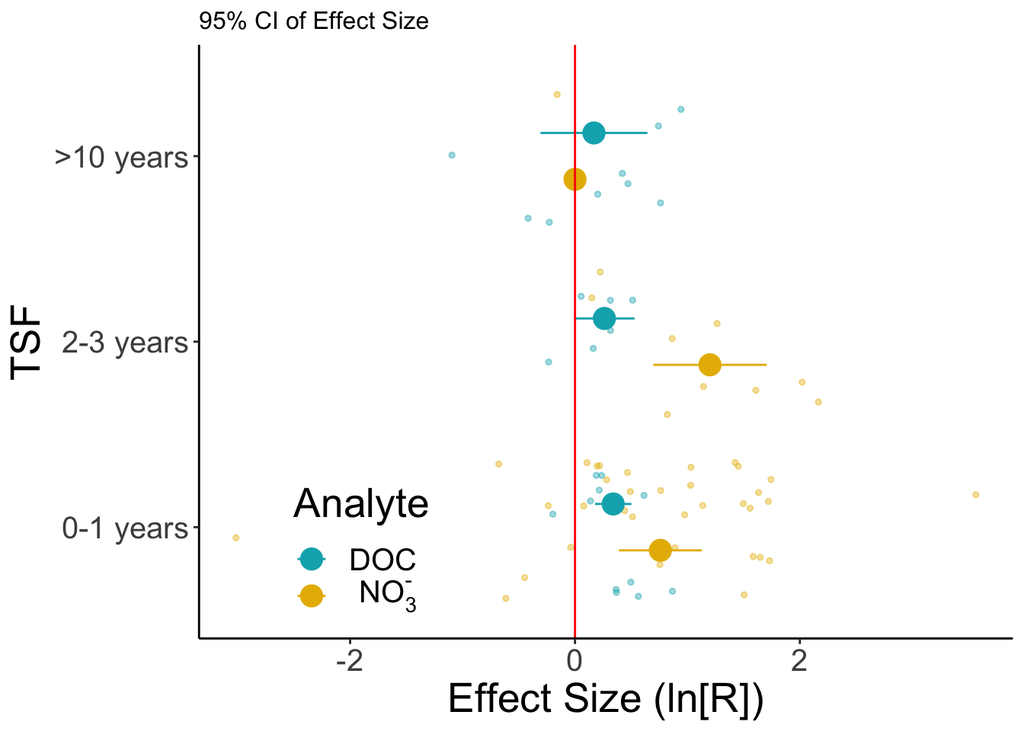

```r
ggsave("site.effect.geom_pointrange.climate.pdf",
       path = ("~/GitHub/rc_sfa-rc-3-wenas-modeling/Lit_Review_Fig/initial_plots/03_Wenas_effect_size"),
       width = 10, height = 8, units = "in")
# geom_jitter for TSF #
# Creating an order in which I want to plot the y-axis
level_order <- c('0-1 years', '2-3 years', '>10 years')

ggplot(effect_size, aes(Effect_size, TSF, color = response_var)) +
  geom_jitter(position = position_jitter(0.2), alpha = 0.4, size = 1) +
  geom_pointrange(aes(xmin = lower_ci_effect, xmax = upper_ci_effect,
                      color = response_var),
                      position = position_dodge(width = -0.5), size = 1.0, data = TSF_summary_effect) +
  geom_vline(xintercept = 0, linewidth = 0.5, color = "red") +
  scale_y_discrete(limit = level_order) +
  xlab("Effect Size (ln[R])") +
  ggtitle("95% CI of Effect Size") +
  scale_color_manual(values = c("#00AFBB", "#E7B800"),
                     guide = guide_legend(title = "Analyte"),
                     labels = c('DOC', vn)) +
  theme_classic() +
  theme(axis.text.x = element_text(size = 15),
        axis.text.y = element_text(size = 15),
        axis.title.x = element_text(size = 20),
        axis.title.y = element_text(size = 20),
        legend.title = element_text(size = 20),
        legend.text = element_text(size = 15),
        legend.position = c(0.2, 0.15),
        title = element_text(size = 10))
```

```r
ggsave("site.difference.geom_pointrange.TSF.pdf",
       path = ("~/GitHub/rc_sfa-rc-3-wenas-modeling/Lit_Review_Fig/initial_plots/03_Wenas_effect_size"),
       width = 10, height = 8, units = "in")
```

### STEP 6 random effects model

```r
mDOC_climate <- lmer(Effect_size ~ Climate + (1|Study_ID), data = effect_size_DOC)
```

```
## boundary (singular) fit: see help('isSingular')
```

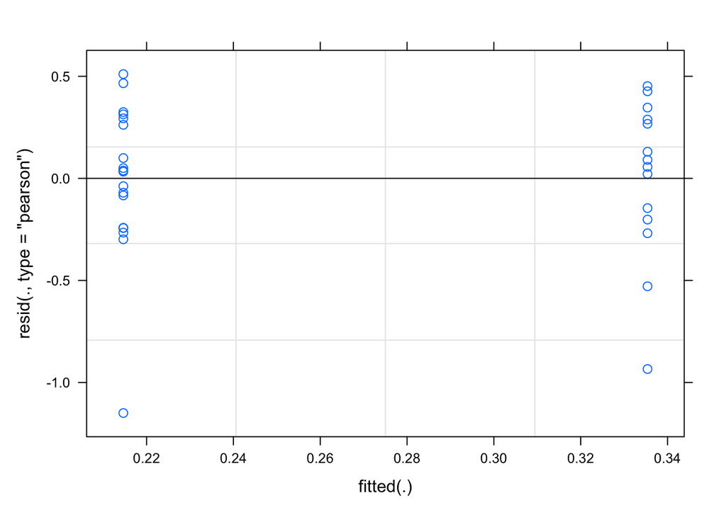

```r
plot(mDOC_climate)
```

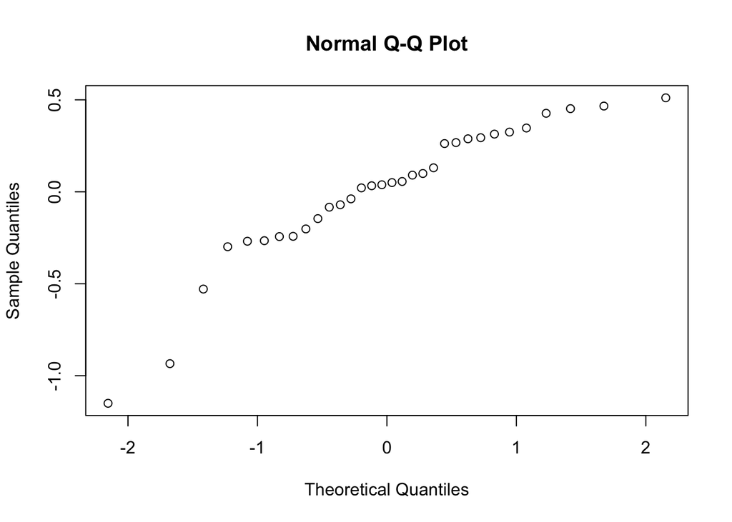

```r
qqnorm(resid(mDOC_climate))
```

```r
anova(mDOC_climate) # f-value = 0.7755
```

```
## Analysis of Variance Table
##         npar  Sum Sq Mean Sq F value
## Climate    1 0.11483 0.11483  0.7755
```

```r
summary(mDOC_climate)
```

```
## Linear mixed model fit by REML ['lmerMod']
## Formula: Effect_size ~ Climate + (1 | Study_ID)
##    Data: effect_size_DOC
##
## REML criterion at convergence: 33.4
##
## Scaled residuals:
##     Min      1Q  Median      3Q     Max
## -2.9881 -0.5508  0.1148  0.7526  1.3276
##
## Random effects:
##  Groups   Name        Variance Std.Dev.
##  Study_ID (Intercept) 0.0000   0.0000
##  Residual             0.1481   0.3848
## Number of obs: 32, groups:  Study_ID, 9
##
## Fixed effects:
##                  Estimate Std. Error t value
## (Intercept)        0.3354     0.1028   3.261
## ClimateTemperate  -0.1208     0.1371  -0.881
##
## Correlation of Fixed Effects:
##             (Intr)
## ClimatTmprt -0.750
## optimizer (nloptwrap) convergence code: 0 (OK)
## boundary (singular) fit: see help('isSingular')
```

Column standard deviation is a measure of how much variability in the dependent measure there is due to the Study_IDs (our random effects). You can see that the Study_ID is adding no additional variance. I think this would suggest that we can use a random intercept model for DOC. The random intercept framework (1|Study_ID) tells the model that it should expect that there are going to be multiple responses per Study_ID and these responses will depend on the Study_ID “baseline” This framework assumes that whatever the effect of effect_size is, its going to be the same for all Study_IDs and considering our variance is 0 I think this is a safe assumption. If this assumption/interpretation is wrong on my end than we can look at doing a random slopes structure which would look like lmer(effect_size ~ Climate + (1+Climate|Study_ID))